# 01desafios

Valentina Paz Campos Olguín

2023-03-25

## Desafío 1

Realice otros 10 ejemplos con diferentes operadores matemáticos.

### 1. Resta

```r
a = 150
b = 30
c = 150 - 30
print(c)
```

```
## [1] 120
```

### 2. Módulo

```r
d <- 4%%2
print(d)
```

```
## [1] 0
```

### 3. Coseno

```r
cosgrad = cos(360*pi/180)
print(cosgrad)
```

```
## [1] 1
```

### 4. Logaritmo natural

```r
print(log(exp(1)))
```

```
## [1] 1
```

### 5. Tangente

```r
print(tan(180*pi/180))
```

```
## [1] -1.224647e-16
```

### 6. Valor absoluto

```r
print(abs(-12312))
```

```
## [1] 12312
```

### 7. Exponencial

```r
print(exp(3))
```

```
## [1] 20.08554
```

### 8. Logaritmo base 2

```r
print(log2(8))
```

```
## [1] 3
```

### 9. Potencia

```r
print(2**6)
```

```
## [1] 64
```

### 10. División entera

```r
print(35%/%3)
```

```
## [1] 11
```

## Desafío 2

Realice ejemplos usando otros tipos de estructura de datos: elementos booleanos, factores, tablas, entre otros.

### 1. Booleanos

```r
es_animal <- TRUE
print(es_animal)
```

```
## [1] TRUE
```

```r
es_flor <- FALSE
print(es_flor)
```

```
## [1] FALSE
```

```r
x <- 5 >= 4
print(x)
```

```
## [1] TRUE
```

```r
x <- 5 > 4
print(x)
```

```
## [1] TRUE
```

```r
x <- 5 == 4
print(x)
```

```
## [1] FALSE
```

```r
x <- 5 <= 4
print(x)
```

```
## [1] FALSE
```

```r
x <- 5 < 4
print(x)
```

```
## [1] FALSE
```

```r
x <- (TRUE | FALSE)
print(x)
```

```
## [1] TRUE
```

```r
x <- (TRUE & FALSE)
print(x)
```

```
## [1] FALSE
```

```r
x <- (TRUE & FALSE) | (TRUE | FALSE)
print(x)
```

```
## [1] TRUE
```

### 2. Factores

```r
animales <- factor(c("caballo", "vaca", "cerdo", "gallina"))
print(animales)
```

```
## [1] caballo vaca    cerdo   gallina
## Levels: caballo cerdo gallina vaca
```

```r
flores <- factor(c("girasol", "tulipán", "rosa", "lirio"))
print(flores)
```

```
## [1] girasol tulipán rosa    lirio
## Levels: girasol lirio rosa tulipán
```

### 3. Tablas

```r
genero <- c("M", "F", "F", "M", "F", "M", "M")

datos <- data.frame(genero)
tabla <- table(datos$genero)

print(tabla)
```

```
##
## F M
## 3 4
```

### 4. Números complejos

```r
complejo <- complex(real = 4, imaginary = 1)
print(complejo)
```

```
## [1] 4+1i
```

## Desafío 3

Construya una función que permita a un jugador jugar al piedra papel o tijeras.

Para este ejemplo se tendrá en cuenta que se jugará con una máquina.

Opción 1: Piedra

Opción 2: Papel

Opción 3: Tijeras

El usuario debe definir la cantidad de victorias que se deben conseguir.

```r
#x tomará el valor de la cantidad de victorias introducida por el usuario.
cachipun <- function(x){
  #Se empieza con 0 puntos tanto para el usuario como para la máquina.
  humano <- 0
  pc <- 0

  #Mientras ninguno de los dos alcance los puntos necesarios, seguirá repitiendo
  #el ciclo.
  while(humano != x && pc != x){
    #Se genera un número al azar entre 1 y 3.
    puntopc = sample(1:3, 1)
    #Se pide un número al usuario entre 1 y 3.
    puntoh = as.integer(readline(prompt="Ingrese: 1. Piedra 2. Papel 3. Tijeras: "))

    #Si el usuario escoge piedra, se analizan los 3 posibles casos que escoja la máquina.
    if(puntoh == 1){
      print("Tú: Piedra")
      if(puntopc == 2){
        print("PC: Papel")
        print("Gana en esta ronda PC")
        #Se aumenta 1 al contador de la máquina.
        pc = pc + 1
      }else if(puntopc == 3){
        print("PC: Tijeras")
        print("Ganas en esta ronda")
        #Se aumenta 1 al contador del usuario.
        humano = humano + 1
      }else{
        print("PC: Piedra")
        print("Empate")
      }
    #Si el usuario escoge papel, se analizan los 3 posibles casos que escoja la máquina.
    }else if(puntoh == 2){
      print("Tú: Papel")
      if(puntopc == 1){
        print("PC: Piedra")
        print("Ganas en esta ronda")
        humano = humano + 1
      }else if(puntopc == 3){
        print("PC: Tijeras")
        print("Gana en esta ronda PC")
        pc = pc + 1
      }else{
        print("PC: Papel")
        print("Empate")
      }
    #Si el usuario escoge tijeras, se analizan los 3 posibles casos que escoja la máquina.
    }else if(puntoh == 3){
      print("Tú: Tijeras")
      if(puntopc == 1){
        print("PC: Piedra")
        print("Gana en esta ronda PC")
        pc = pc + 1
      }else if(puntopc == 2){
        print("PC: Papel")
        print("Ganas en esta ronda")
        humano = humano + 1
      }else{
        print("PC: Tijeras")
        print("Empate")
      }
    #Si el usuario escoge otro número, se repite la pregunta.
    }else{
      print("Elección incorrecta")
    }
  }

  #Si los puntos del humano son mayores al de la máquina, gana el usuario.
  if(humano > pc){
    print(paste("Ganaste con ", humano, " puntos."))
    print(paste("El computador perdió con", pc, " puntos."))
  #Caso contrario, gana la máquina.
  }else{
    print(paste("Ganó el computador con", pc, " puntos."))
    print(paste("Perdiste con", humano, " puntos."))
  }
}
```

```r
#Aquí se introduce la cantidad de victorias necesarias para ganar el juego.
#x_1 <- as.integer(readline(prompt="Por favor, ingrese la cantidad de victorias: "))
```

```r
#Se llama la función con el número anterior.
#cachipun(x_1)
```

Ejemplo de uso

```r
#Por favor, ingrese la cantidad de victorias: 1
#Ingrese: 1. Piedra 2. Papel 3. Tijeras: 3
#[1] "Tú: Tijeras"
#[1] "PC: Piedra"
#[1] "Gana en esta ronda PC"
#[1] "Ganó el computador con 1  puntos."
#[1] "Perdiste con 0  puntos."
```

## Desafío 4

### 1.

Seleccione un conjunto de datos desde el paquete ‘datasets’ de R. Para ver los datasets disponibles en la consola puede utilizar la función “data()” o puede consultarlos en la página web https://stat.ethz.ch/R-manual/R-devel/library/datasets/html/00Index.html. Una vez seleccionado puede utilizar la función data(‘nombre_del_dataset’) para cargar el dataset.

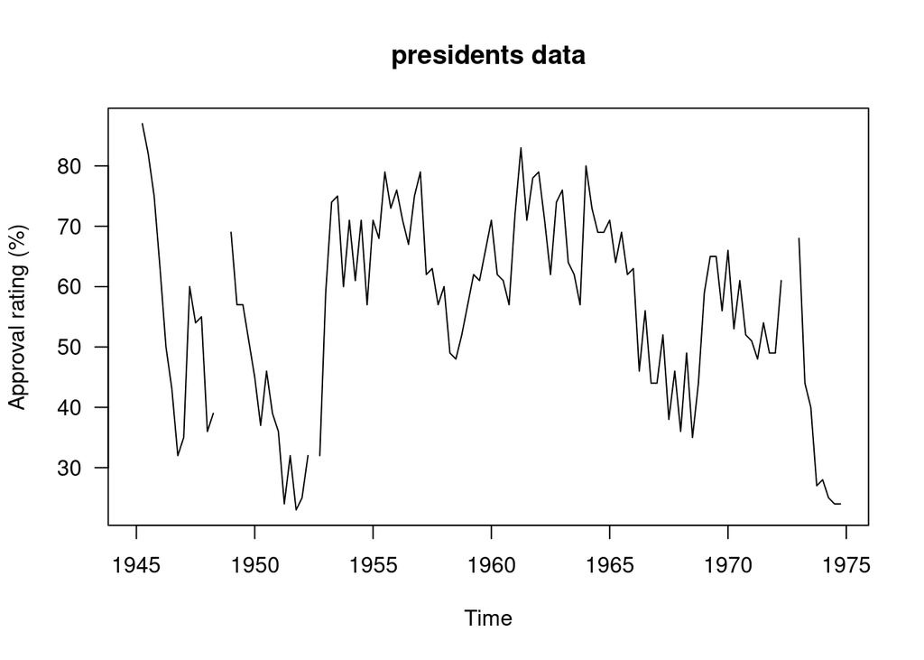

```r
require(stats); require(graphics)
plot(presidents, las = 1, ylab = "Approval rating (%)",
     main = "presidents data")
```

### 2.

Describa el conjunto de datos y explique para que fue o podría ser utilizado. Puede usar la función help(‘nombre_del_dataset’). ¿Cuál es la fuente de los datos?

```r
help(presidents)
```

El conjunto de datos datos muestra el porcentaje de aprobación de los distintos presidentes que ha tenido Estados Unidos entre 1945 y 1975. Este puede ser utilizado para analizar qué espectros políticos se ven más favorables, cuáles se ven en desventaja a lo largo de los años, y a su vez quién ha sido el presidente con mayor aprobación promedio y cuál ha sido el presidente con menor aprobación promedio.

La fuente de los datos es The Gallup Organisation y ocupan como referencia el libro llamado *Interactive Data Analysis* de Donald Raymond McNeil.

### 3.

Describa cada variable, indique a qué tipo de variable corresponde, indique qué valores puede tomar y su unidad de medida.

- **Variable independiente: Tiempo**

  Esta variable corresponde a los años, entre 1945 y 1975, donde gobernaron distintos presidentes en los Estados Unidos. Puede tomar valores naturales del 1945 a 1975 y además se separan en cuartiles.
- **Variable dependiente: Aprobación**

  Esta variable corresponde a la aprobación que han tenido los diversos presidentes según el tiempo qué gobernaron. Puede tomar valores enteros entre 0 y 100, o NA. Se mide en porcentaje.

### 4.

Ejecute la función summary(“conjunto_de_datos”). ¿Qué puede observar?

```r
summary(presidents)
```

```
##    Min. 1st Qu.  Median    Mean 3rd Qu.    Max.    NA's
##   23.00   46.00   59.00   56.31   69.00   87.00       6
```

### 5.

Ejecute la función plot(“conjunto_de_datos”). ¿Qué puede observar?

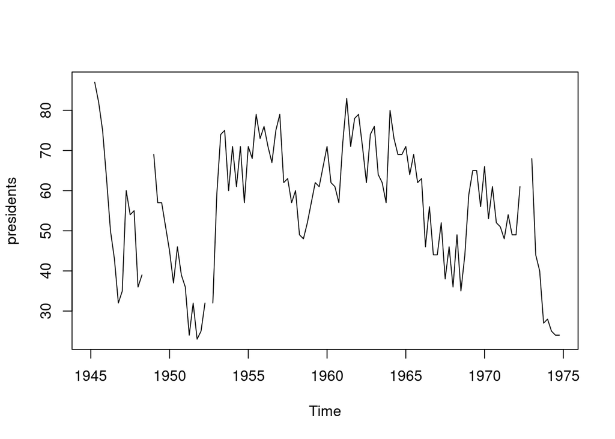

```r
plot(presidents)
```